# Pharmaceutical Drug SpendingAnalysis

## By Moumita Das

### Problem Statement

Pharmaceutical spending covers expenditure on prescription medicines and self-medication often referred to asover-the-counter products. In some countries, other medical non-durable goods are also included. Pharmaceuticalsconsumed in hospitals and other health care settings are excluded. Final expenditure on pharmaceuticals includeswholesale and retail margins and value-added tax. Total pharmaceutical spending refers in most countries to “net”spending, i.e. adjusted for possible rebates payable by manufacturers, wholesalers, or pharmacies. This indicator ismeasured as a share of total health spending, in USD per capita (using economy-wide PPPs) and as a share of GDP. Within these data, lies important patterns and variables that can be used by pharmaceutical companies to planbusiness strategies. Find out some interesting insights from the data provided to you and make a dashboard usingany BI tool (such as Tableau, Power BI, etc ). Make a summary report based on your analysis.

#### Importing all libraries

```python
import pandas as pd # for reading the file
import numpy as np # for numericals & mathematicals experssion
import seaborn as sns # for data visulization
import matplotlib.pyplot as plt # for data visulization
%matplotlib inline
import time
import warnings
warnings.filterwarnings('ignore')
```

```python
pip install pandas-profiling
```

```python
data = pd.read_csv("pharmaceutical-drug-spending.csv")
```

```python
from pandas_profiling import ProfileReport
profile = ProfileReport(data, title="Pandas Profiling Report")
```

```python
profile
```

[interactive chart not shown]

- We are not so interested about missing values corresponding to the column FLAG_CODES.

```python
data.describe()
```

|  | TIME | PC_HEALTHXP | PC_GDP | USD_CAP | TOTAL_SPEND |
| --- | --- | --- | --- | --- | --- |
| count | 1036.000000 | 1036.000000 | 1036.000000 | 1036.000000 | 1036.000000 |
| mean | 1996.809846 | 16.406307 | 1.170948 | 295.046989 | 11765.423118 |
| std | 12.498330 | 6.389064 | 0.465635 | 209.152134 | 34878.286123 |
| min | 1970.000000 | 5.545000 | 0.207000 | 3.160000 | 6.290000 |
| 25% | 1987.000000 | 11.516250 | 0.768250 | 111.098500 | 728.180000 |
| 50% | 1999.000000 | 14.967500 | 1.141500 | 266.332000 | 2349.570000 |
| 75% | 2007.000000 | 20.590500 | 1.523250 | 446.109500 | 7778.180000 |
| max | 2016.000000 | 40.239000 | 2.797000 | 1162.399000 | 373009.910000 |

#### Let's first clean the already existing columns

```python
data = data.drop(columns={'FLAG_CODES'}).astype({'LOCATION': 'category'}).set_index(['LOCATION', 'TIME'])
data
```

| LOCATION | TIME | PC_HEALTHXP | PC_GDP | USD_CAP | TOTAL_SPEND |
| --- | --- | --- | --- | --- | --- |
| AUS | 1971 | 15.992 | 0.727 | 35.720 | 462.11 |
|  | 1972 | 15.091 | 0.686 | 36.056 | 475.11 |
|  | 1973 | 15.117 | 0.681 | 39.871 | 533.47 |
|  | 1974 | 14.771 | 0.755 | 47.559 | 652.65 |
|  | 1975 | 11.849 | 0.682 | 47.561 | 660.76 |
| ... | ... | ... | ... | ... | ... |
| LTU | 2012 | 28.942 | 1.820 | 448.728 | 1340.70 |
|  | 2013 | 28.173 | 1.728 | 461.178 | 1364.02 |
|  | 2014 | 27.836 | 1.724 | 485.245 | 1422.92 |
|  | 2015 | 26.784 | 1.745 | 504.422 | 1465.30 |
| RUS | 2015 | 22.939 | 1.286 | 309.900 | 44655.62 |

1036 rows × 4 columns

# Exploratory Data Analysis

### Data Visualization

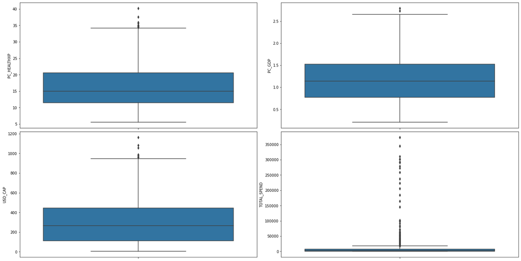

```python
fig,ax = plt.subplots(ncols = 2,nrows = 2 ,figsize = (20,10))
index = 0
ax = ax.flatten()

for cols, value in data.items():
    if cols != 'type':
        sns.boxplot(y=cols,data = data,ax=ax[index])
        index += 1

plt.tight_layout(pad = 0.5,w_pad = 0.7,h_pad = 0.7)
plt.show()
```

```python
data[data['PC_HEALTHXP']>34]
```

| LOCATION | TIME | PC_HEALTHXP | PC_GDP | USD_CAP | TOTAL_SPEND |
| --- | --- | --- | --- | --- | --- |
| HUN | 2011 | 35.001 | 2.653 | 603.042 | 6013.37 |
| MEX | 2003 | 35.894 | 2.134 | 230.651 | 24366.08 |
|  | 2004 | 35.048 | 2.120 | 242.481 | 25944.40 |
|  | 2005 | 35.603 | 2.108 | 260.194 | 28223.82 |
|  | 2006 | 34.725 | 1.984 | 267.984 | 29503.00 |
| SVK | 1999 | 34.810 | 1.928 | 206.344 | 1113.44 |
|  | 2000 | 34.690 | 1.843 | 209.134 | 1126.96 |
|  | 2001 | 34.657 | 1.851 | 229.487 | 1234.38 |
|  | 2002 | 37.564 | 2.072 | 275.505 | 1481.37 |
|  | 2003 | 40.239 | 2.196 | 310.549 | 1668.70 |
|  | 2004 | 34.185 | 2.215 | 336.670 | 1808.69 |
| LTU | 2005 | 34.341 | 1.937 | 281.439 | 935.09 |

```python
data[data["PC_GDP"]>2.7]
```

| LOCATION | TIME | PC_HEALTHXP | PC_GDP | USD_CAP | TOTAL_SPEND |
| --- | --- | --- | --- | --- | --- |
| GRC | 2010 | 28.633 | 2.737 | 771.997 | 8585.64 |
|  | 2011 | 30.742 | 2.797 | 731.159 | 8119.45 |

```python
data[data["USD_CAP"]>950]
```

| LOCATION | TIME | PC_HEALTHXP | PC_GDP | USD_CAP | TOTAL_SPEND |
| --- | --- | --- | --- | --- | --- |
| CHE | 2013 | 14.083 | 1.600 | 956.715 | 7739.20 |
|  | 2014 | 13.895 | 1.610 | 985.969 | 8073.75 |
|  | 2015 | 14.014 | 1.690 | 1056.053 | 8746.65 |
| USA | 2011 | 11.855 | 1.939 | 965.580 | 300935.91 |
|  | 2012 | 11.459 | 1.874 | 964.237 | 302768.85 |
|  | 2013 | 11.384 | 1.858 | 980.864 | 310154.01 |
|  | 2014 | 11.968 | 1.981 | 1081.402 | 344495.16 |
|  | 2015 | 12.227 | 2.068 | 1162.399 | 373009.91 |

- percent of health spending outlier - 791-792 index value,US dollars per capita outlier - 913,970,971 index value,percent of GDP outlier - 360-361 index value

```python
data.drop(data.index[[360,361,791,792,913,970,971]], inplace = True)
```

```python
data.shape
```

```
(1029, 4)
```

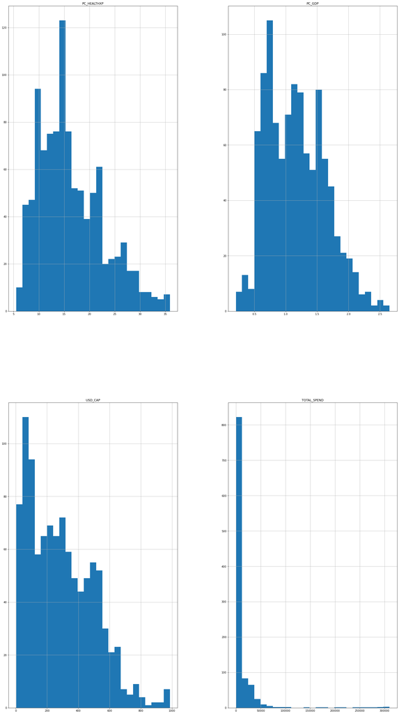

```python
data.hist(bins = 25, figsize = (27,50))
plt.show()
```

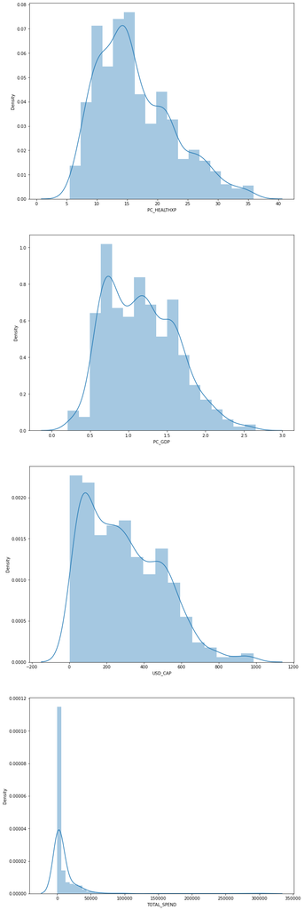

```python
fig, ax = plt.subplots(ncols = 1, nrows = 4, figsize = (10, 30))
index = 0
ax = ax.flatten()

for col, value in data.items():
    if col != 'type':
        sns.distplot(value, ax = ax[index])
        index += 1
plt.tight_layout(pad = 0.5, w_pad = 0.7, h_pad = 5.0)
```

```python
data.corr()
```

|  | PC_HEALTHXP | PC_GDP | USD_CAP | TOTAL_SPEND |
| --- | --- | --- | --- | --- |
| PC_HEALTHXP | 1.000000 | 0.722466 | 0.144407 | 0.019426 |
| PC_GDP | 0.722466 | 1.000000 | 0.671658 | 0.340572 |
| USD_CAP | 0.144407 | 0.671658 | 1.000000 | 0.478654 |
| TOTAL_SPEND | 0.019426 | 0.340572 | 0.478654 | 1.000000 |

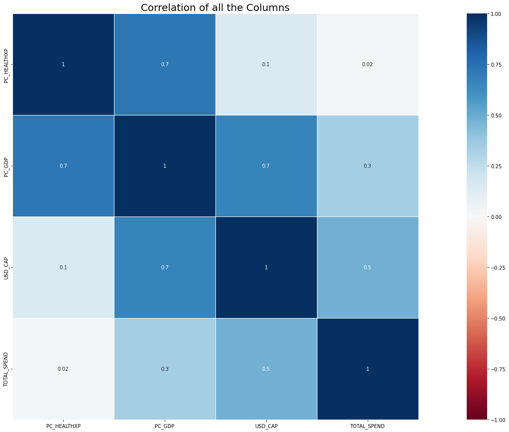

```python
plt.figure(figsize = (35,15))
plt.title('Correlation of all the Columns', fontsize = 20)
sns.heatmap(data.corr(), annot = True, vmin = -1, vmax = 1, center = 0, fmt = '.1g', linewidths = 1, linecolor = 'white',
            square = True, cmap ='RdBu')
```

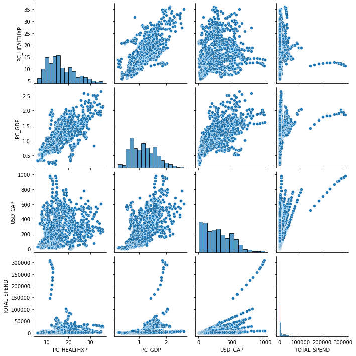

```python
sns.pairplot(data)
```

```python
import plotly.express as px
import plotly.graph_objects as go
fig = px.line(data, x=data.index.get_level_values('TIME'), y="PC_HEALTHXP", color=data.index.get_level_values('LOCATION'))
fig.add_trace(go.Scatter(x=data.groupby('TIME').mean().index, y=data.groupby('TIME').mean()["PC_HEALTHXP"], mode='lines', line={'width': 6, 'color': 'black'}, name='Mean'))
fig.show()
```

[interactive chart not shown]

- We see fluctuations in the PC_HEALTHXP(percent of health spending) across the years but on first sight there isn't a direct pattern.

```python
fig = px.line(data, x=data.index.get_level_values('TIME'), y="PC_GDP", color=data.index.get_level_values('LOCATION'))
fig.add_trace(go.Scatter(x=data.groupby('TIME').mean().index, y=data.groupby('TIME').mean()["PC_GDP"], mode='lines', line={'width': 6, 'color': 'black'}, name='Mean'))
fig.show()
```

[interactive chart not shown]

- percent of GDP across the years

```python
fig = px.line(data, x=data.index.get_level_values('TIME'), y="USD_CAP", color=data.index.get_level_values('LOCATION'))
fig.add_trace(go.Scatter(x=data.groupby('TIME').mean().index, y=data.groupby('TIME').mean()["USD_CAP"], mode='lines', line={'width': 6, 'color': 'black'}, name='Mean'))
fig.show()
```

[interactive chart not shown]

- US dollars per capita for specific countries.

```python
fig = px.line(data, x=data.index.get_level_values('TIME'), y="TOTAL_SPEND", color=data.index.get_level_values('LOCATION'))
fig.add_trace(go.Scatter(x=data.groupby('TIME').mean().index, y=data.groupby('TIME').mean()["TOTAL_SPEND"], mode='lines', line={'width': 6, 'color': 'black'}, name='Mean'))
fig.show()
```

[interactive chart not shown]

- Total spending by countries through the years

```python
fig = px.scatter(data, y="PC_GDP", x="USD_CAP", color=data.index.get_level_values('LOCATION'))
fig.add_trace(go.Scatter(x=pd.cut(data['USD_CAP'],15, retbins=True)[1], y=data.groupby(pd.cut(data['USD_CAP'],15, retbins=True)[0]).mean()["PC_GDP"], mode='lines', line={'width': 6, 'color': 'black'}, name='Mean'))
fig.show()
```

[interactive chart not shown]

```python
fig = px.scatter(data, y="PC_HEALTHXP", x="USD_CAP", color=data.index.get_level_values('LOCATION'))
fig.add_trace(go.Scatter(x=pd.cut(data['USD_CAP'],15, retbins=True)[1], y=data.groupby(pd.cut(data['USD_CAP'],15, retbins=True)[0]).mean()["PC_HEALTHXP"], mode='lines', line={'width': 6, 'color': 'black'}, name='Mean'))
fig.show()
```

[interactive chart not shown]

- However, we do not see the same correlation in PC_HEALTHXP which seems to suggest that if nations spent more per capita on drugs, it is because they spent more on healthcare in general. Thus there is no/little correlation between USD_CAP and PC_HEALTHXP